# 50 años de la Ciencia de los Datos

15 de febrero de 2023

## Ciencia de los Datos (CD) vs. Estadística

- “Data Science Initiative” (DSI) es un movimiento de la Universidad de Michigan anunciado en 2015 con un presupuesto de 100MDD.
- Los estadísticos se sienten excluidos del “Data Science Movement”.
- Para ellos, mucho de lo que representa CD no es nada nuevo.
- Las definiciones tanto de DS como de la Estadística pueden ser en muchos casos intercambiables.

**“Científico de datos” se refiere a un profesional que utiliza métodos científicos para liberar y crear significado a partir de datos sin procesar.**

“Estadística” significa la práctica o la ciencia de recopilar y analizar datos numéricos en grandes cantidades.

- Claramente hay muchas visiones de la CD y su relación con la estadística. A continuación se presentan algunos de estos temas recurrentes.

## Big Data (BD)

- BD no es algo exactamente nuevo. Por ejemplo: desde hace cientos de años se han ejecutado censos de población.
- Los estadísticos siempre se han sentido cómodos con grandes conjuntos de datos como estos.
- Dentro de la estadística se crearon herramientas para tratar con BD como lo son el “muestreo” y la “suficiencia”.
- DS = BD no obtiene nada demasiado sustancial en las áreas involucradas.

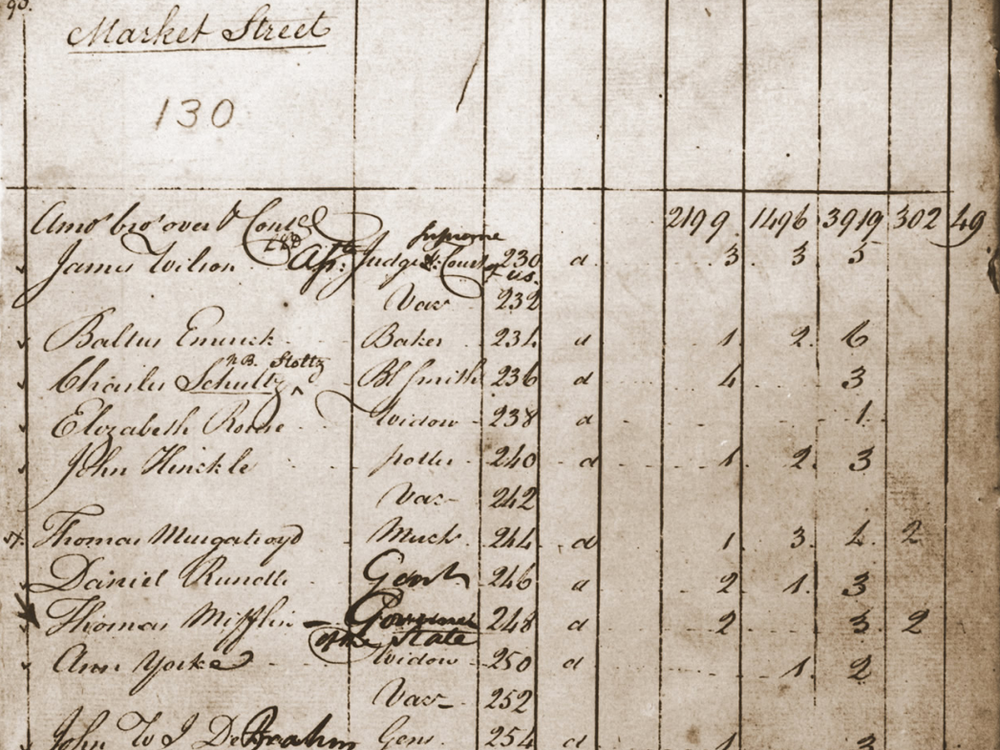

Extracto del primer censo en EEUU en 1790

## Enseñando una Mejor Ciencia de los Datos

## Investigación en una Mejor Ciencia de los Datos

## Los siguientes 50 años para la Ciencia de los Datos

## Ciencia abierta

## Ciencia como datos

## Análisis Cientifico de los Datos

## La Ciencia de los Datos en 2065